# Final_Project_DAINES

Austin Daines

# $Bball

This project is inspired by *Moneyball*: The Art of Winning an Unfair Game, a book by Michael Lewis, published in 2003, about the Oakland Athletics baseball team and its general manager Billy Beane. Its focus is the team’s analytical, evidence-based, sabermetric approach to assembling a competitive baseball team despite Oakland’s small budget ([Wiki source](https://en.wikipedia.org/wiki/Moneyball)).

*In 2001 the Oakland Athletics team salary was only **34 million dollars** compared to the league leading **112 million dollar** New York Yankees.*

The discrepancy in team salary is not as drastic in the NBA.

Here I took a web scraping function from [mbjoseph](https://rdrr.io/github/mbjoseph/bbr/src/R/zzz.R) to scrape NBA team salaries.

```
## [1] "Web scraping hoopshype.com/salaries..."
```

```
## [1] "Loaded 30 team salaries."
```

Here are the (6) largest team salaries:

```
##           Team  X2020.21
## 1 Golden State 170722835
## 2     Brooklyn 169052492
## 3 Philadelphia 147840679
## 4  LA Clippers 139722606
## 5    LA Lakers 138326578
## 6         Utah 136048278
```

#### Boxplot of team salary:

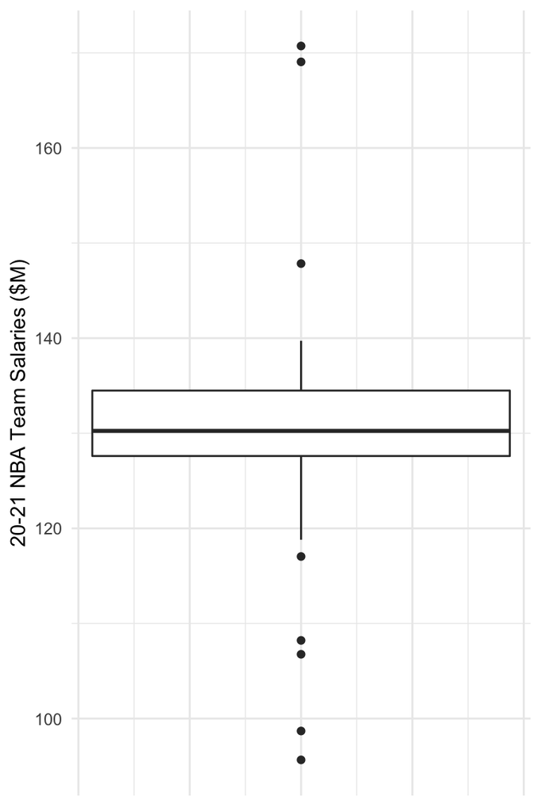

In 2001 the Oakland A’s paid about 1/2 the median MLB team salary. With this in mind we will attempt to build a competitive team with 1/2 the median NBA team salary. Here we see the median team salary in the NBA is roughly $130 million. That leaves us with 65 million dollars to work with.

### Hypothesis

Similar to baseball, we can create a competitive team with a salary of $65M.

#### What constitutes a competitive team?

Well, that’s not a simple question to answer. We need a team with players who contribute both offensively and defensively. First, we will analyze plus-minus statistics

##### Plus-Minus

- [Plus-Minus](https://www.nbastuffer.com/analytics101/plus-minus/), a.k.a. +/-, simply keeps track of the net changes in the score when a given player is either on or off the court.

##### Real Plus-Minus

- [Real Plus-Minus](https://www.nbastuffer.com/analytics101/real-plus-minus-rpm/) can be broken down into offensive and defensive metrics:
  - Offensive Real Plus-Minus: (ORPM): Player’s average impact on his team’s offensive performance, by the points scored per 100 offensive possessions.
  - Defensive Real Plus-Minus: (DRPM): Player’s average impact on his team’s defensive performance, by the points allowed per 100 offensive possessions.

##### RPM Wins

- [RPM Wins](http://www.espn.com/nba/statistics/rpm#:~:text=Glossary&text=WINS%3A%20%22RPM%20Wins%22%20provide,his%20number%20of%20possessions%20played.) provide an estimate of the number of wins each player has contributed to his team’s win total on the season. RPM Wins include the player’s Real Plus-Minus and his number of possessions played.

Before analyzing player statistics we need to know how much each player is worth. Let’s load individual player salaries.

```
## [1] "Web scraping hoopshype.com/salaries/players/..."
```

```
## [1] "Loaded 577 player salaries."
```

#### Boxplot of NBA player salaries:

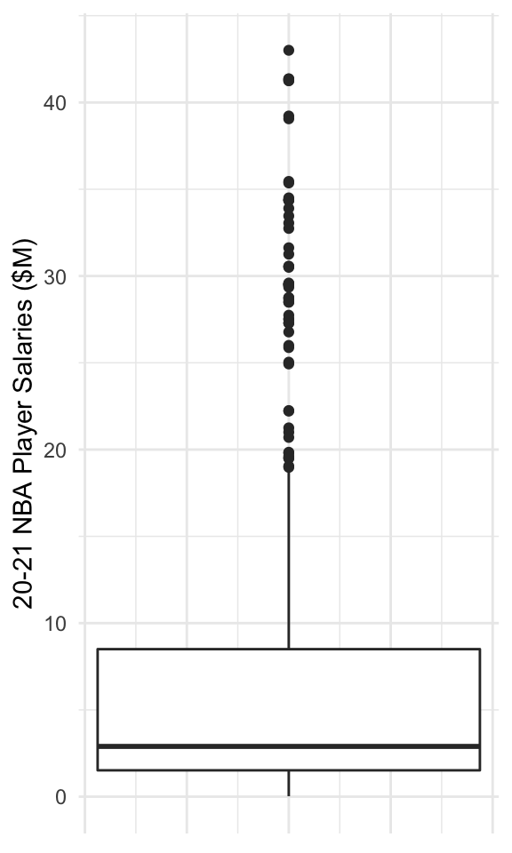

Curious how much your favorite player makes? Search and see!

| Player | X2020.21 |
| --- | --- |
| Stephen Curry | 43006362 |
| Chris Paul | 41358814 |
| Russell Westbrook | 41358814 |
| James Harden | 41254920 |
| John Wall | 41254920 |
| LeBron James | 39219566 |
| Kevin Durant | 39058950 |
| Paul George | 35450412 |
| Klay Thompson | 35361360 |
| Mike Conley | 34502132 |

[output cut: 567 more lines]

```
## [1] "Web scraping espn.com/nba/statistics/..."
```

```
## [1] "Loaded 10 statistics for 526 players."
```

```
##   RK                Player TEAM GP  MPG  ORPM  DRPM  RPM  WINS POS
## 1  1         Stephen Curry   GS 58 34.1  6.93 -0.07 6.87 17.18  PG
## 2  2          LeBron James  LAL 43 33.7  4.64  2.06 6.69 11.56  SF
## 3  3           Rudy Gobert UTAH 64 30.9 -1.32  7.49 6.17 14.33   C
## 4  4 Giannis Antetokounmpo  MIL 55 33.2  3.93  1.21 5.13 12.72  PF
## 5  5           Paul George  LAC 50 33.6  1.84  3.11 4.95 10.36  SG
## 6  6           Joel Embiid  PHI 46 31.7  2.13  2.72 4.85  9.02   C
```

```
## [1] "Add player salary as final column to player stats"
```

```
##   RK                Player TEAM GP  MPG  ORPM  DRPM  RPM  WINS POS X2020.21
## 1  1         Stephen Curry   GS 58 34.1  6.93 -0.07 6.87 17.18  PG 43006362
## 2  2          LeBron James  LAL 43 33.7  4.64  2.06 6.69 11.56  SF 39219566
## 3  3           Rudy Gobert UTAH 64 30.9 -1.32  7.49 6.17 14.33   C 26775281
## 4  4 Giannis Antetokounmpo  MIL 55 33.2  3.93  1.21 5.13 12.72  PF 27528088
## 5  5           Paul George  LAC 50 33.6  1.84  3.11 4.95 10.36  SG 35450412
## 6  6           Joel Embiid  PHI 46 31.7  2.13  2.72 4.85  9.02   C 29542010
```

#### Analyzing RPM vs. Salary

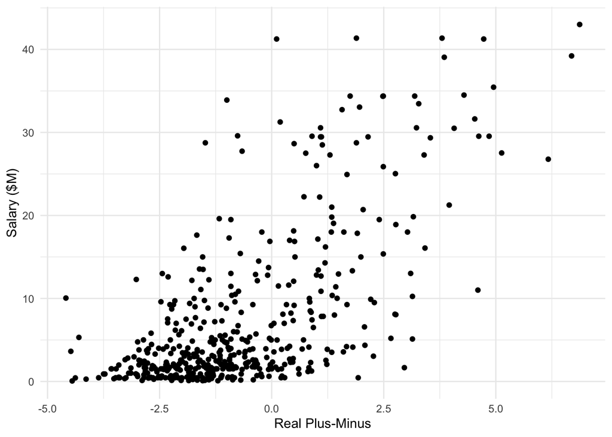

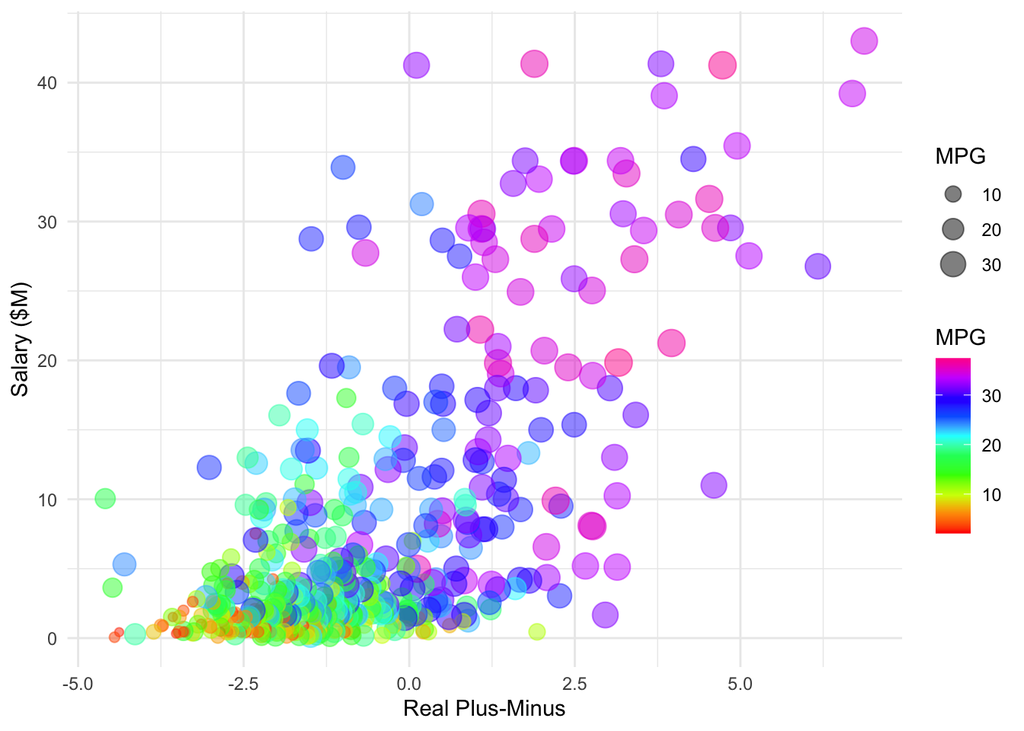

#### What’s going on?

##### The chart on the left is a plain scatterplot mess. On the right we can understand the data a little bit more. *In general, players that play more minutes are paid more and have a higher plus/minus.* This might make things difficult for us because we need a competitive team that is cheap!

## Time to collect more data

Our Plus/Minus stats come from [NBA.com](https://stats.nba.com/stats/leaguedashplayerstats).

Also, we will web scrape the data thanks to some help from our guy [Ashwin](https://towardsdatascience.com/how-scraping-nba-stats-is-cooler-than-michael-jordan-49d7562ce3ef).

```
## [1] "Web scraping stats.nba.com/stats/..."
```

```
## [1] "Loaded 65 statistics for 532 players."
```

Now that we have all the individual player statistics we could ever need to analyze a player’s value we will shift over to compile NBA team statistics.

```
## [1] "Web scraping nba.com/standings ..."
```

```
## [1] "Loaded 81 stats for 30 teams."
```

```
## [1] "Cleaned and reduced to 8 stats (including salary) for 30 teams."
```

###### Why the team stats?

These stats will be enable us to test how competitively our team stacks up against other teams in the NBA.

```
##           Team TeamName  W  L   PPG OppPPG DiffPointsPG  X2020.21
## 1      Phoenix     Suns 47 18 114.8  108.5          6.3 128858241
## 2 Philadelphia    76ers 44 21 113.6  108.2          5.4 147840679
## 3         Utah     Jazz 47 18 116.3  107.2          9.1 136048278
## 4     Brooklyn     Nets 43 23 118.7  114.5          4.2 169052492
## 5    Milwaukee    Bucks 41 24 119.4  113.1          6.3 135449418
## 6           LA Clippers 44 22 114.2  108.2          6.0 139722606
```

#### Team Salary vs. Team Wins

Let’s see if spending more money translates to winning more games.

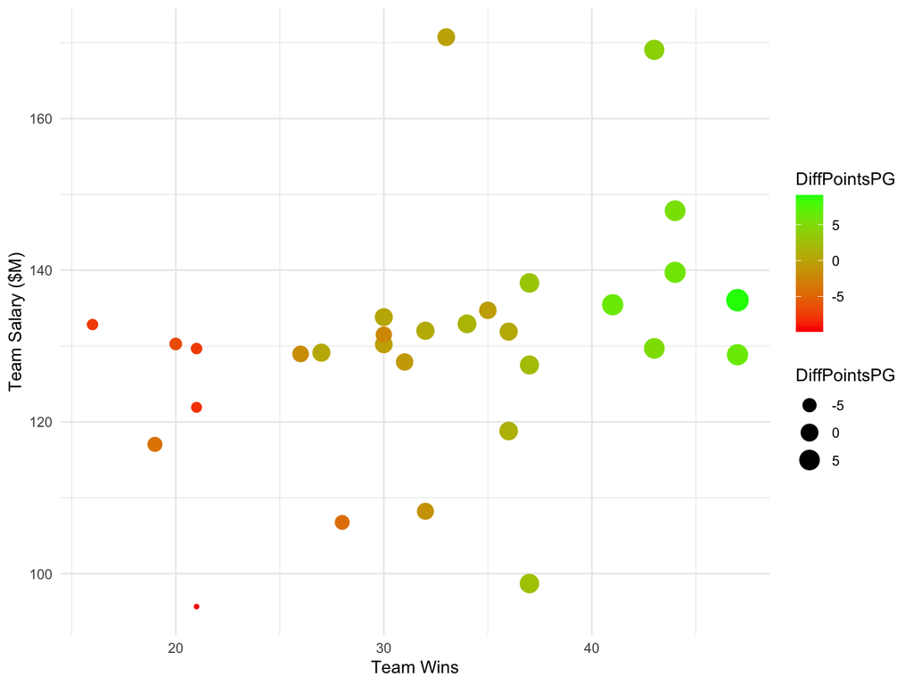

Looking at the data another way we observe a **pattern** that might be obvious.

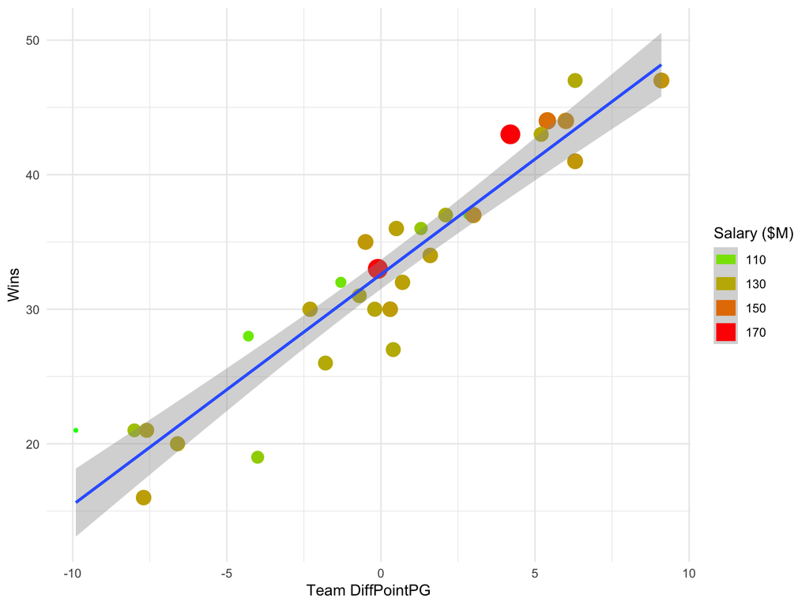

### Wins and DiffPointPG

- These stats are generally correlated
- Higher DiffPointPG translates to more Wins
- However, higher salary doesn’t always correlate with more wins
  - There are lower salary teams with better PPG and Wins!

This finding gives us hope. It opens the door a little bit more for being able to *build a winning team* on a low budget.

### Now what?

Well, we have evidence that it is possible to be a competitive team with a lower end budget. Let’s see how far we can stretch the limits now that we have all the player and team statistics we need for analysis.

#### First, let’s filter out players…

- With few minutes (we need players!)
- And a Plus/Minus < 200 (we need good players)
- With salaries over $15M (we need affordable players)

```
## [1] "Now we have 16 players to analyze."
```

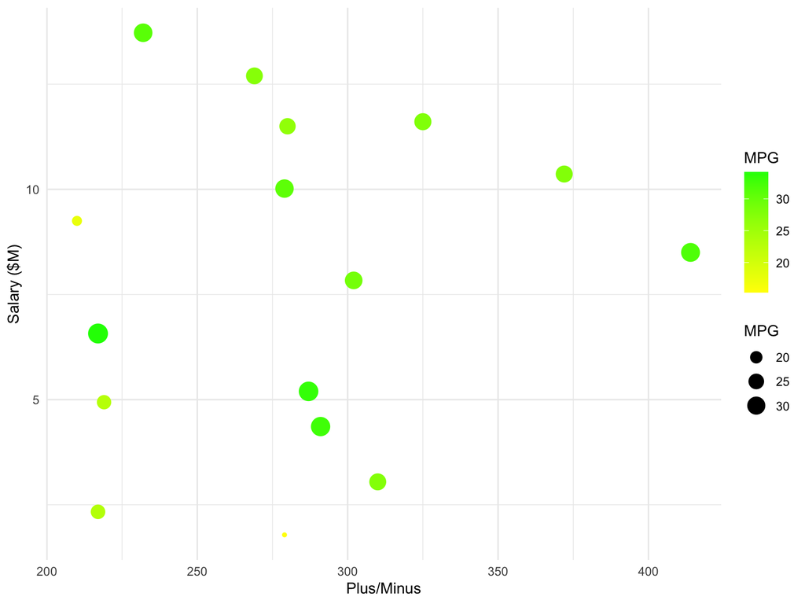

```
## [1] "Here is the composition of the team:"
```

```
##
##   C  PF  PG  SF  SG
##   1   2   2   2   5
```

```
## [1] "Here is the team:"
```

```
##              Player POS  MPG   P_M_PG X2020.21
## 1     Georges Niang  SF 15.3 4.292308  1783557
## 2    Reggie Jackson  PG 23.1 3.500000  2331593
## 3  Donte DiVincenzo  SG 27.5 5.166667  3044160
## 4     Mikal Bridges  SF 32.8 4.476923  4359000
## 5   Pat Connaughton  SG 22.8 3.532258  4938273
## 6  Donovan Mitchell  SG 33.4 5.415094  5195501
## 7        Trae Young  PG 34.2 3.807018  6571800
## 8        Seth Curry  SG 28.9 5.807692  7834449
## 9     Royce O'Neale  PF 31.8 6.468750  8500000
## 10      Dario Saric  PF 17.5 4.772727  9250000
## 11    Deandre Ayton   C 30.7 4.292308 10018200
## 12       Joe Ingles  SG 27.6 6.200000 10363637
```

```
## [1] "The salary is 74.2 M"
```

From the analysis of plus/minus we filtered out a team that is slightly outside of our budget and guard heavy. Not bad for a first attempt. Let’s keep going with real plus minus.

#### Attempt 2: let’s filter out players…

- With few minutes (we need players!)
- And a Real Plus Minus < 1.8 (we need good players)
- With salaries over $15M (we need affordable players)

```
## [1] "Now we have 14 players to analyze."
```

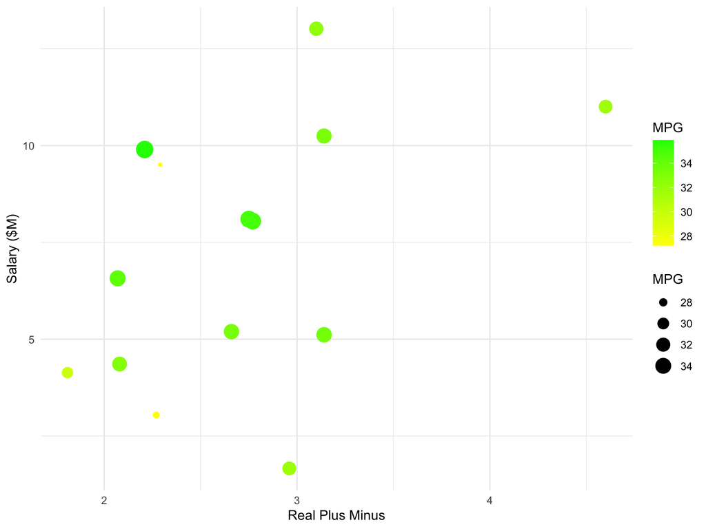

```
## [1] "Here is the composition of the team:"
```

```
##
##   C  PF  PG  SF  SG
##   1   2   3   3   3
```

```
## [1] "Here is the team:"
```

```
##              Player POS  MPG  RPM X2020.21
## 1   Duncan Robinson  SG 31.8 2.96  1663861
## 2  Donte DiVincenzo  SG 27.5 2.27  3044160
## 3      John Collins  PF 29.7 1.81  4137302
## 4     Mikal Bridges  SF 32.8 2.08  4359000
## 5       Bam Adebayo   C 33.5 3.14  5115492
## 6  Donovan Mitchell  SG 33.4 2.66  5195501
## 7        Trae Young  PG 34.2 2.07  6571800
## 8       Luka Doncic  PG 35.1 2.77  8049360
## 9      De'Aaron Fox  PG 35.1 2.75  8099627
## 10    Kyle Anderson  SF 27.2 2.29  9505100
## 11     Jayson Tatum  SF 35.9 2.21  9897120
## 12  Zion Williamson  PF 33.2 3.14 10245480
```

```
## [1] "The salary is 75.9 M"
```

From the analysis of real plus/minus, again, we filtered out a team that is slightly outside of our budget, but looking more like a normal lineup. Not bad for a second attempt. Let’s keep going with real plus/minus wins.

#### Attempt 3: let’s filter out players…

- With few minutes (we need players!)
- And a RPM WINS < 5 (we need good players)
- With salaries over $15M (we need affordable players)

```
## [1] "Now we have 24 players to analyze."
```

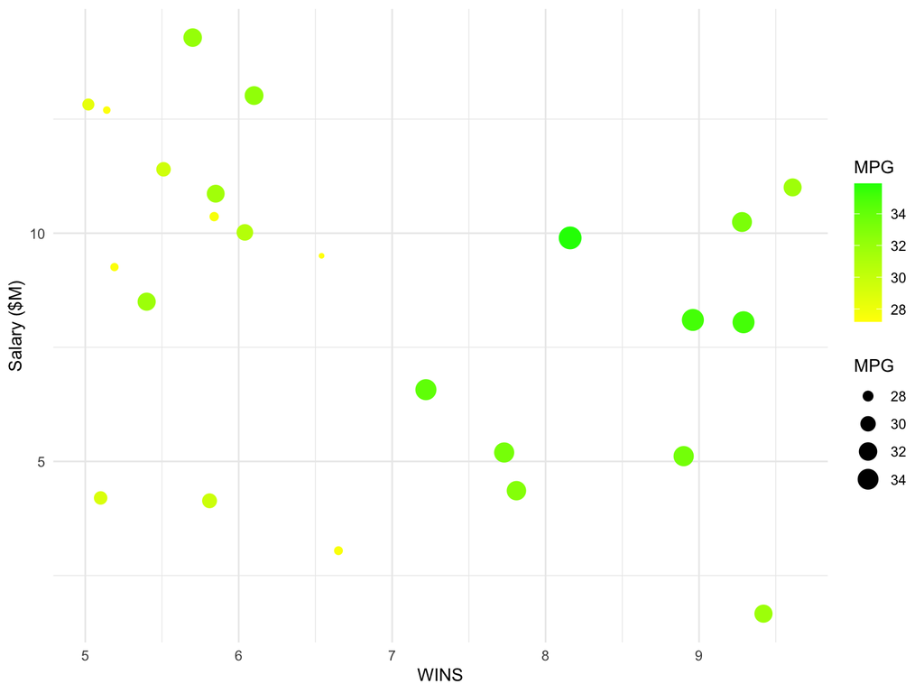

```
## [1] "Here is the composition of the team:"
```

```
##
##   C  PF  PG  SF  SG
##   1   3   3   2   3
```

```
## [1] "Here is the team:"
```

```
##              Player POS  MPG WINS X2020.21
## 1   Duncan Robinson  SG 31.8 9.42  1663861
## 2  Donte DiVincenzo  SG 27.5 6.65  3044160
## 3      John Collins  PF 29.7 5.81  4137302
## 4    Reggie Bullock  SF 29.0 5.10  4200000
## 5     Mikal Bridges  SF 32.8 7.81  4359000
## 6       Bam Adebayo   C 33.5 8.90  5115492
## 7  Donovan Mitchell  SG 33.4 7.73  5195501
## 8        Trae Young  PG 34.2 7.22  6571800
## 9       Luka Doncic  PG 35.1 9.29  8049360
## 10     De'Aaron Fox  PG 35.1 8.96  8099627
## 11    Royce O'Neale  PF 31.8 5.40  8500000
## 12      Jae Crowder  PF 27.4 5.19  9258000
```

```
## [1] "The salary is 68.2 M"
```

#### Ayyoo!

Now we are in business. Out of the 24 players selected we chose to stick with the 12 players that were the least expensive. This landed us less than $3.5 million above our salary cap. Considering only 4 of 30 NBA teams are under the league salary cap we will consider this a major win.

## Now, the real question:

### Can this newly created $Bball team compete with current teams?

- Let’s test by pro-rating RPM WINS vs. existing league leaders’ RPM WINS

```
## [1] "The top  team is: Phoenix with 47 wins and 18 losses."
```

#### Our team will play a similar style to other NBA teams:

- players 1-3 will play 34 minutes per game (mpg),
- players 4-8 will play 24 mpg,
- players 9 & 10 will play 9 mpg,
- and players 11 & 12 will be reserves.

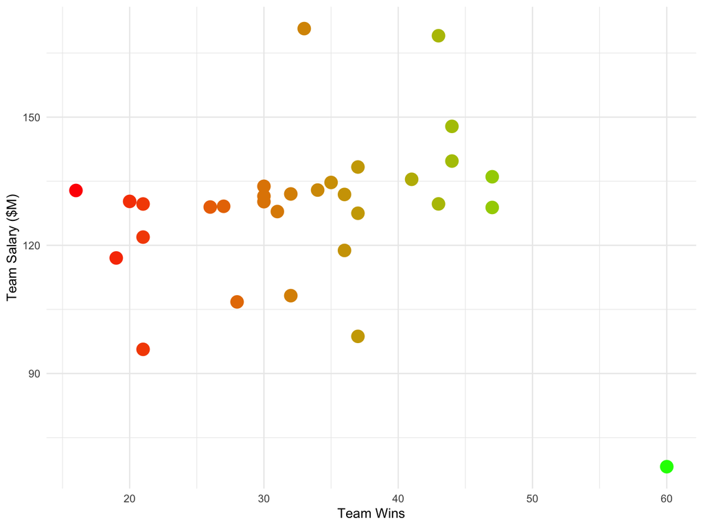

```
## [1] "Our $Bball team, with a salary of 68.2M, has a projected W-L record of 60-5!!!"
```

## Success!

###### We are on track to head into the playoffs as the **number 1 overall team**! At this rate we may even post the best record of all-time.